# NARS Data Innovation Challenge

Linnea Rock

2022-07-20

### What are the sizes of lakes sampled during the NLA?

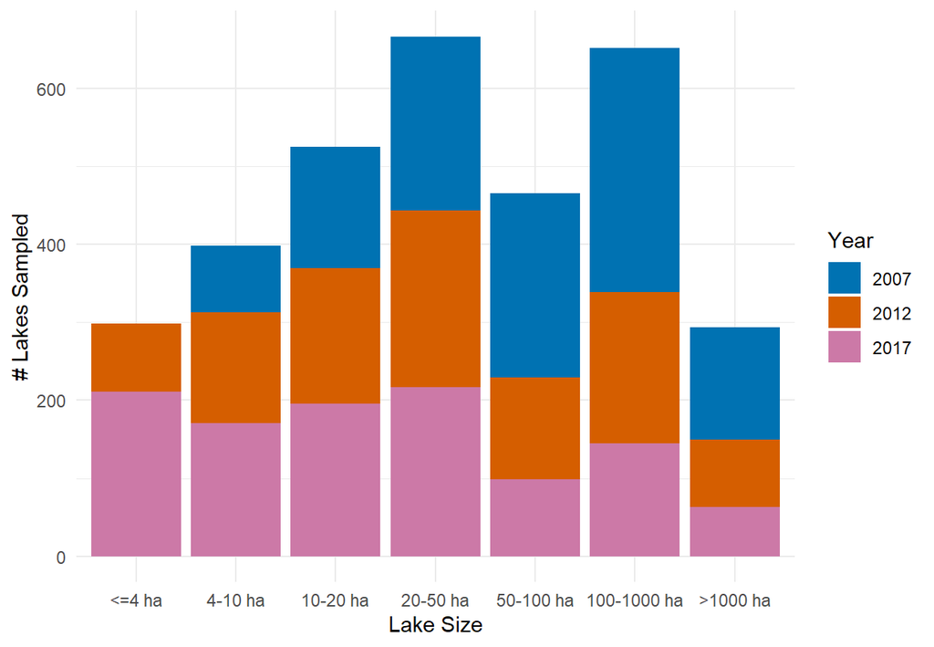

### Locations of lakes sampled in 2017

#### Lakes colored by trophic status

[output not shown]

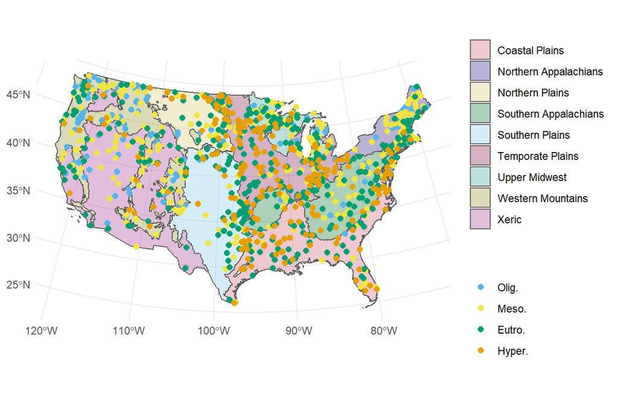

#### Logged TN:TP molar ratios across the US in 2017

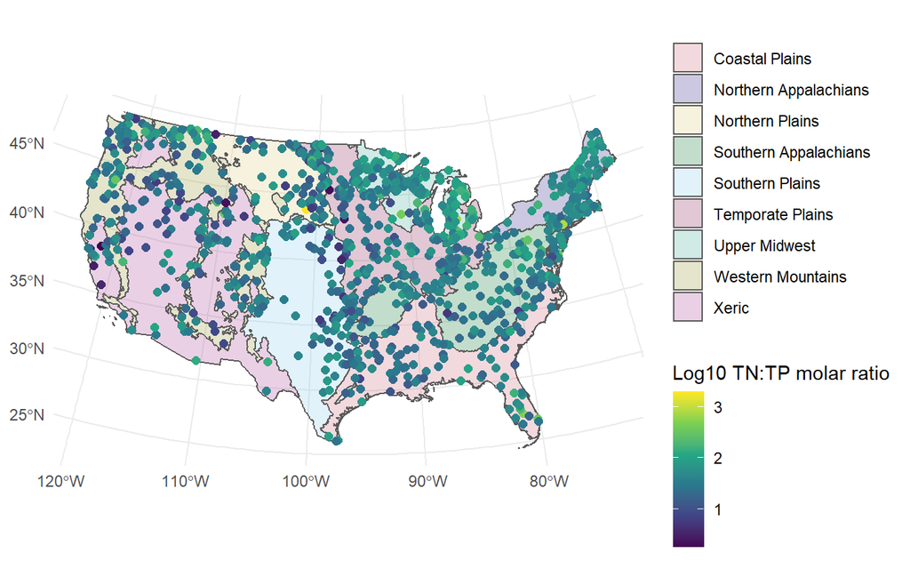

### Trophic states across US ecoregions

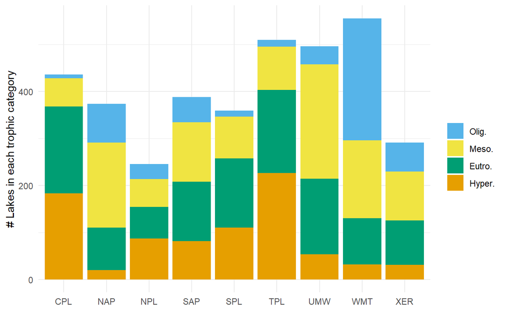

### N and P limitations from the literature.

#### Looking at the NLA data with N and P limits from Bergström, 2010. The predicted limitations are above/below the dotted lines. The red line is the Redfield 16:1 line.

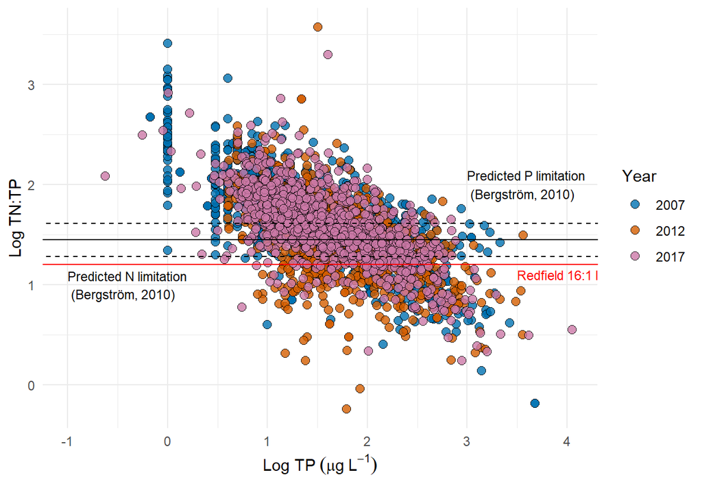

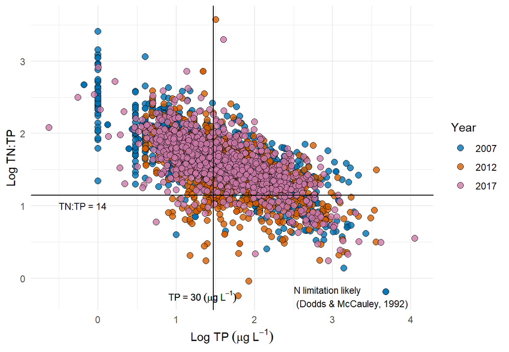

### Nitrogen vs. Phosphorus and Trophic Status

Note: the axes are logged in these figures

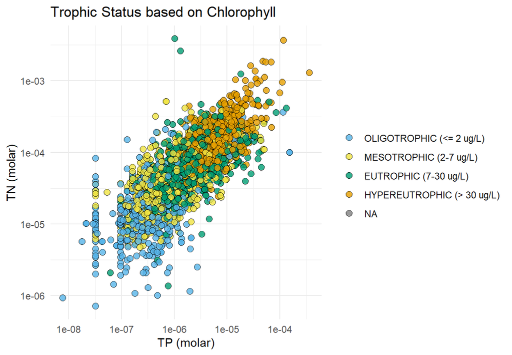

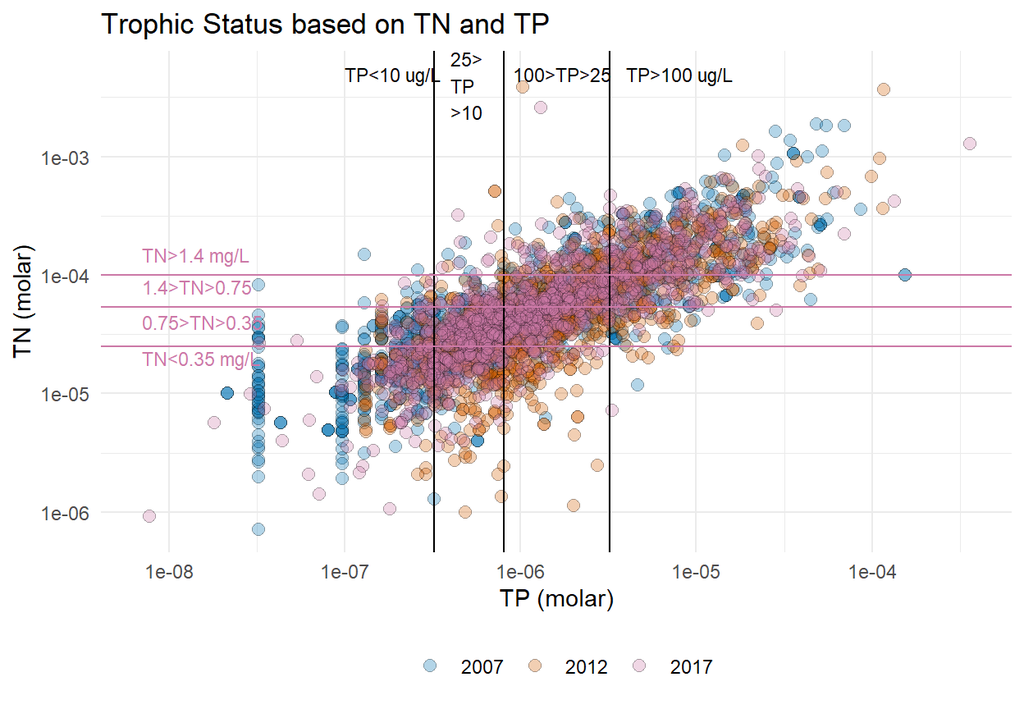

### Nutrient relationships with Chlorophyll

Note: axes are logged in these figures

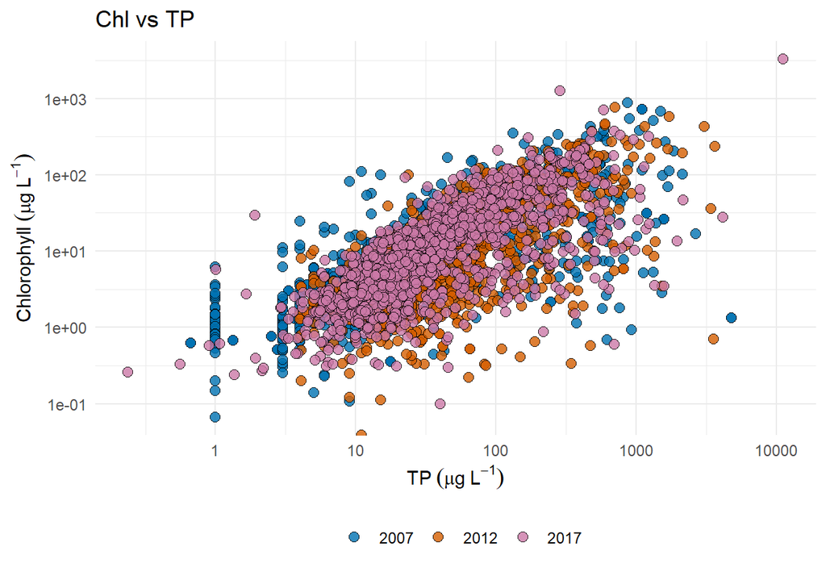

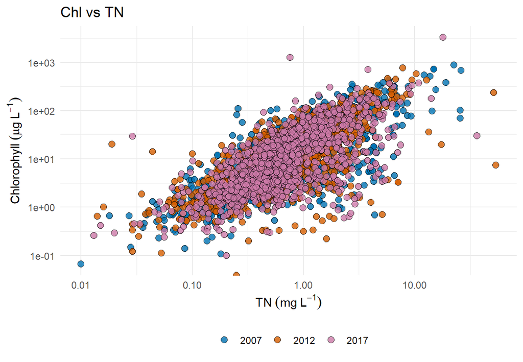

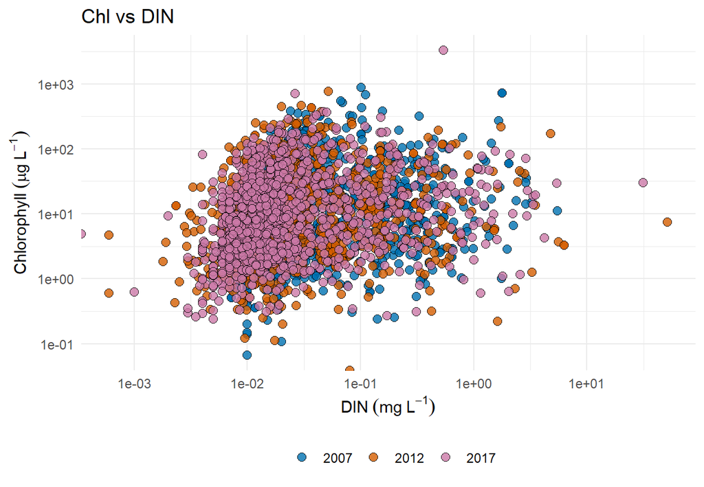

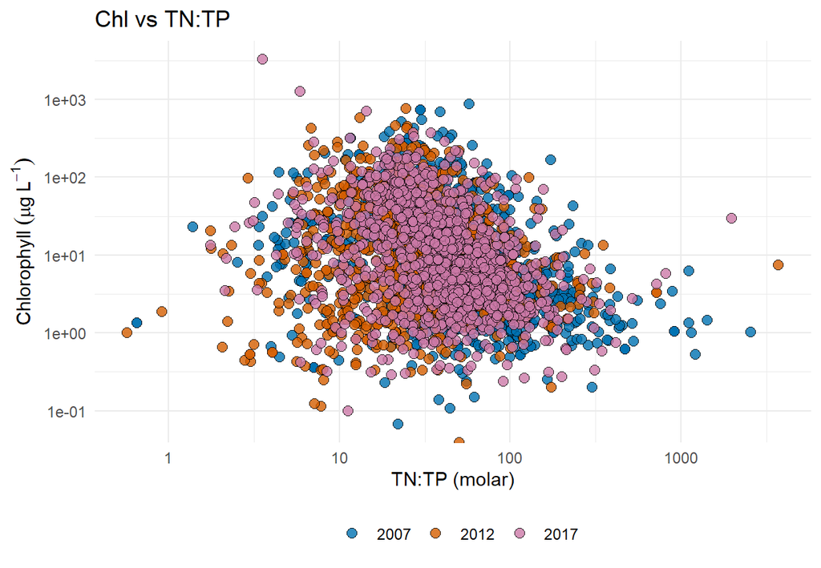

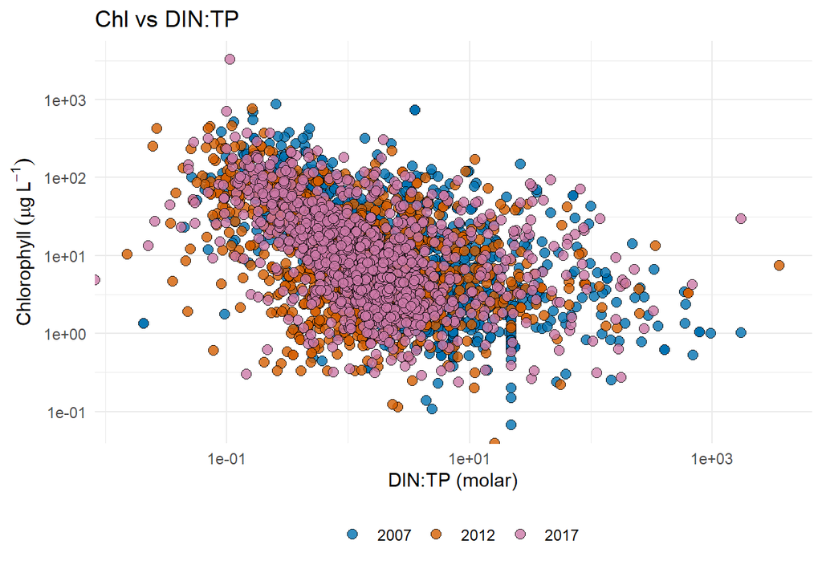

### Number of lakes in each trophic category

| OLIGOTROPHIC (<= 2 ug/L) 2007 | MESOTROPHIC (2-7 ug/L) 2007 | EUTROPHIC (7-30 ug/L) 2007 | HYPEREUTROPHIC (> 30 ug/L) 2007 | OLIGOTROPHIC (<= 2 ug/L) 2012 | MESOTROPHIC (2-7 ug/L) 2012 | EUTROPHIC (7-30 ug/L) 2012 | HYPEREUTROPHIC (> 30 ug/L) 2012 | OLIGOTROPHIC (<= 2 ug/L) 2017 | MESOTROPHIC (2-7 ug/L) 2017 | EUTROPHIC (7-30 ug/L) 2017 | HYPEREUTROPHIC (> 30 ug/L) 2017 |
| --- | --- | --- | --- | --- | --- | --- | --- | --- | --- | --- | --- |
| National |  |  |  |  |  |  |  |  |  |  |  |
| 222 ( 11.6 ± 1.6 ) | 404 ( 34 ± 2.3 ) | 384 ( 31.7 ± 2.3 ) | 311 ( 22.7 ± 1.9 ) | 173 ( 10 ± 1.4 ) | 348 ( 32.2 ± 3.3 ) | 346 ( 34.9 ± 2.9 ) | 265 ( 22.9 ± 2.5 ) | 168 ( 9.8 ± 1.6 ) | 368 ( 23.5 ± 2.1 ) | 416 ( 43.8 ± 3.6 ) | 247 ( 22.9 ± 2.4 ) |
| Coastal Plains |  |  |  |  |  |  |  |  |  |  |  |
| 1 ( 0 ± 0 ) | 11 ( 4 ± 1.6 ) | 62 ( 60.1 ± 6.4 ) | 65 ( 35.8 ± 6.2 ) | 4 ( 1.7 ± 0.8 ) | 21 ( 13.6 ± 3.6 ) | 63 ( 51.7 ± 6.1 ) | 58 ( 32.9 ± 5.6 ) | 3 ( 6.2 ± 4.8 ) | 28 ( 11.1 ± 2.8 ) | 60 ( 48 ± 7 ) | 60 ( 34.6 ± 6.4 ) |
| Northern Appalachians |  |  |  |  |  |  |  |  |  |  |  |
| 38 ( 24.4 ± 6.4 ) | 68 ( 51.5 ± 7.1 ) | 26 ( 19.9 ± 4.2 ) | 6 ( 4.2 ± 1 ) | 22 ( 15.1 ± 4.7 ) | 58 ( 54.1 ± 11.1 ) | 27 ( 17.5 ± 4.9 ) | 6 ( 13.3 ± 8.7 ) | 22 ( 16.4 ± 4.6 ) | 55 ( 59.2 ± 6 ) | 37 ( 20.6 ± 3.9 ) | 8 ( 3.7 ± 1.3 ) |
| Northern Plains |  |  |  |  |  |  |  |  |  |  |  |
| 10 ( 6.4 ± 4.3 ) | 21 ( 21 ± 6.1 ) | 19 ( 40.2 ± 10.5 ) | 33 ( 32.4 ± 7 ) | 12 ( 15.1 ± 5.5 ) | 17 ( 11.7 ± 3.4 ) | 20 ( 35.9 ± 7.9 ) | 29 ( 37.2 ± 7.3 ) | 10 ( 9.5 ± 3.5 ) | 21 ( 19.7 ± 5.3 ) | 28 ( 29.6 ± 6.1 ) | 25 ( 41.2 ± 6.6 ) |
| Southern Appalachians |  |  |  |  |  |  |  |  |  |  |  |
| 27 ( 12.4 ± 4.5 ) | 55 ( 30.6 ± 6.3 ) | 44 ( 33.4 ± 6.2 ) | 30 ( 23.5 ± 5.9 ) | 16 ( 15.5 ± 7 ) | 29 ( 11.8 ± 2.7 ) | 31 ( 39.8 ± 7.1 ) | 28 ( 32.9 ± 7.2 ) | 11 ( 6.8 ± 3.1 ) | 42 ( 12.8 ± 5.2 ) | 52 ( 59 ± 9.4 ) | 23 ( 21.4 ± 7.3 ) |
| Southern Plains |  |  |  |  |  |  |  |  |  |  |  |
| 7 ( 7.7 ± 3.8 ) | 33 ( 17.7 ± 6.2 ) | 62 ( 39 ± 8.7 ) | 56 ( 35.6 ± 8.2 ) | 3 ( 1.5 ± 1.3 ) | 27 ( 35.6 ± 11.1 ) | 34 ( 16.3 ± 5.6 ) | 31 ( 46.7 ± 12.3 ) | 3 ( 1 ± 0.8 ) | 29 ( 17.2 ± 6.5 ) | 51 ( 48.5 ± 10 ) | 23 ( 33.2 ± 10.8 ) |
| Temperate Plains |  |  |  |  |  |  |  |  |  |  |  |
| 4 ( 1.1 ± 0.6 ) | 31 ( 25 ± 6.1 ) | 56 ( 30.7 ± 4.7 ) | 84 ( 43.1 ± 4.9 ) | 5 ( 0.9 ± 0.4 ) | 31 ( 22.3 ± 6.2 ) | 57 ( 42.4 ± 7.9 ) | 71 ( 34.4 ± 6 ) | 5 ( 1.5 ± 0.9 ) | 30 ( 8.1 ± 2.7 ) | 64 ( 59.7 ± 11.1 ) | 71 ( 30.7 ± 8.8 ) |
| Upper Midwest |  |  |  |  |  |  |  |  |  |  |  |
| 16 ( 8.8 ± 3.6 ) | 96 ( 57 ± 5.6 ) | 46 ( 24.7 ± 5 ) | 17 ( 9.5 ± 3.5 ) | 8 ( 4.4 ± 1.7 ) | 71 ( 54.9 ± 6.8 ) | 55 ( 35.2 ± 6.1 ) | 16 ( 5.5 ± 2 ) | 15 ( 11.2 ± 4.3 ) | 76 ( 35.7 ± 5.3 ) | 60 ( 40.3 ± 6.4 ) | 20 ( 12.7 ± 3 ) |
| Western Mountains |  |  |  |  |  |  |  |  |  |  |  |
| 98 ( 44.6 ± 6.7 ) | 53 ( 31.4 ± 6 ) | 39 ( 12.3 ± 4.8 ) | 11 ( 11.8 ± 3.2 ) | 82 ( 58.7 ± 7.8 ) | 59 ( 30.9 ± 6.9 ) | 28 ( 7.9 ± 2.3 ) | 9 ( 2.4 ± 0.9 ) | 79 ( 45.1 ± 6.2 ) | 54 ( 40.4 ± 6.4 ) | 31 ( 12.4 ± 2.3 ) | 12 ( 2.2 ± 0.7 ) |
| Xeric |  |  |  |  |  |  |  |  |  |  |  |
| 21 ( 21.3 ± 5.2 ) | 36 ( 25.5 ± 5.4 ) | 30 ( 25.9 ± 5.4 ) | 9 ( 27.2 ± 8.7 ) | 21 ( 26.6 ± 6.6 ) | 35 ( 21.5 ± 4.7 ) | 31 ( 35 ± 7.1 ) | 17 ( 17 ± 6.7 ) | 20 ( 16.5 ± 7.5 ) | 33 ( 35.3 ± 10.6 ) | 33 ( 34.8 ± 7.7 ) | 5 ( 13.4 ± 7.1 ) |

### How have the lakes changed trophic category over the years?

#### Looking at the difference between 2017 and 2007

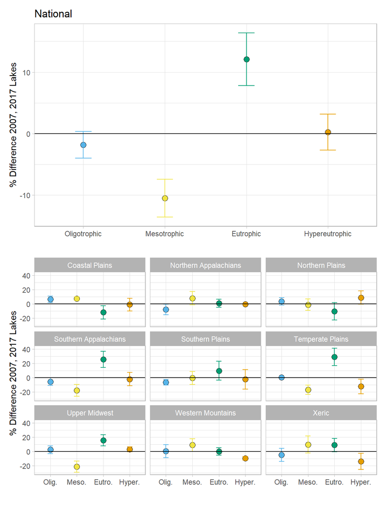

I can’t add these until I determine what to do with double samplings

### Boxplots showing how concentrations and ratios vary across trophic states in the most recent NLA survey (2017)

#### Trophic states based on chlorophyll

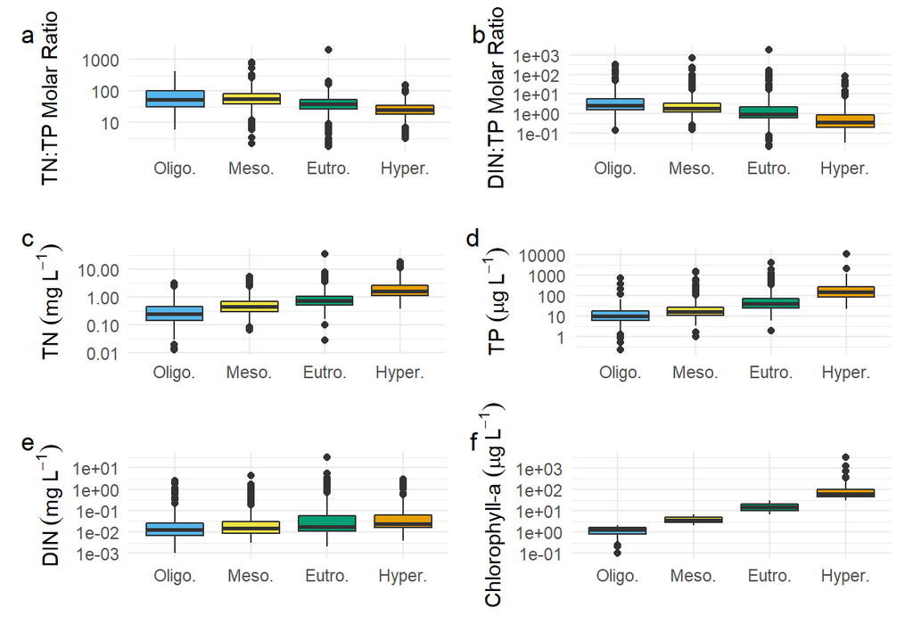

### Comparisons between years in resampled lakes

#### TN:TP ratio differences between 2007 and 2017. Red line is 1:1, or no change.

Note: there are a lot of doubles here. I need to determine what to do about lakes that are sampled twice.

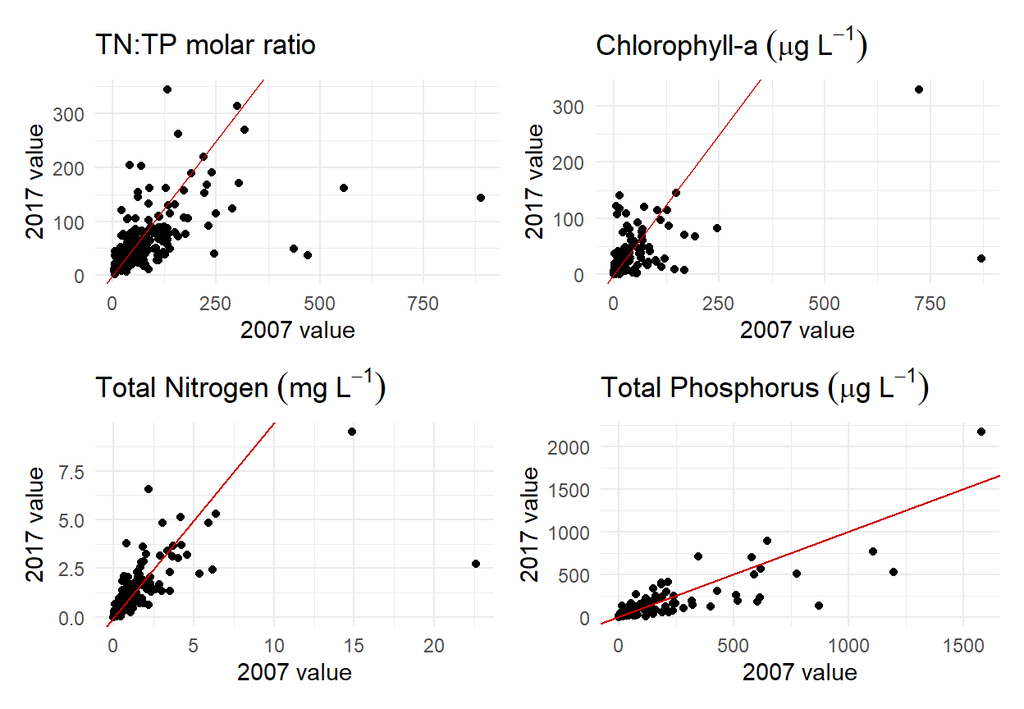

### How do trophic statuses and stoichiometries compare across ecoregions in natural vs. manmade lakes in 2017?

#### Logged axes

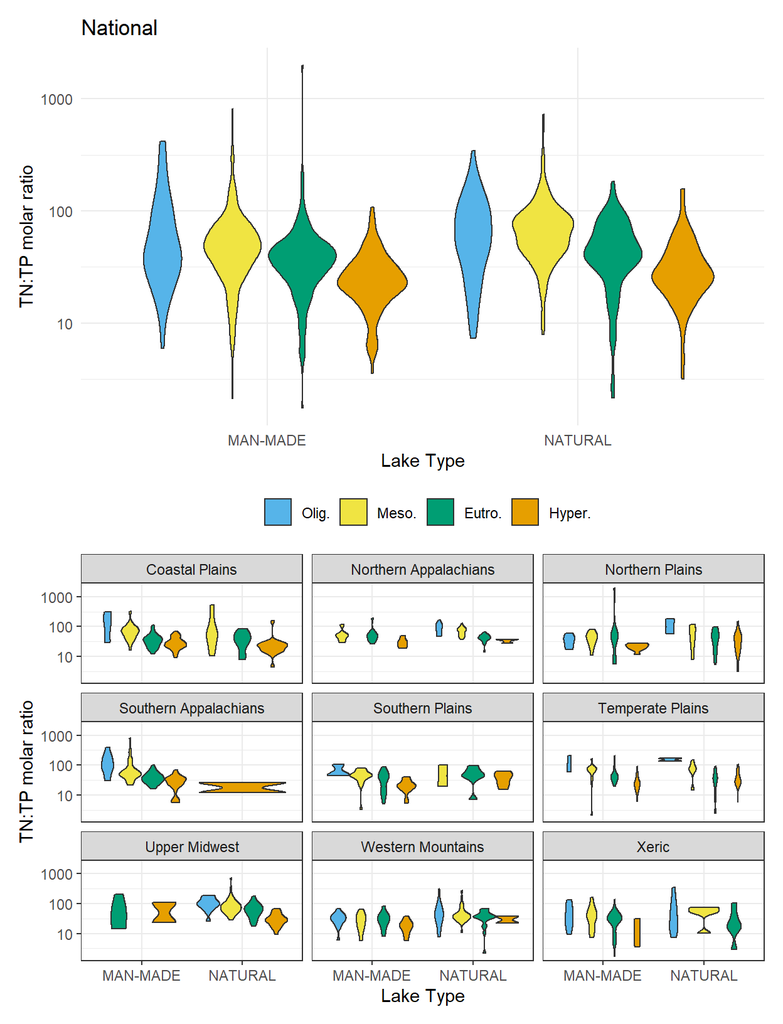